# Primary_GCN_gtex

Amy Hicks

15/12/2021

[CoExp (Garcia-Ruiz et al., 2021)](https://www.ncbi.nlm.nih.gov/pmc/articles/PMC7943635/) contains **five** packages which contain gene co-expression networks constructed using data from **four** independent databases of tissue-specific transcriptomic data. **Frontal cortex** is the one tissue common to all of these databases. This markdown contains an exploration of the **GTEx version 6** frontal cortex gene co-expression network downloaded from [GitHub](https://github.com/juanbot?tab=repositories). This package contains data from [GTEx consortium](https://gtexportal.org/home/) which provides 53 different human tissues from a total of 544 healthy donors. Each network contains many modules which represent the clusters of coexpression. Relationships between the nine genes of the non-specific (**NSL**) complex and several other lists of genes of interest (see `Genelists.Rmd`) were examined.

```r
# First initialise the datasets/packages to use
CoExpGTEx::initDb(mandatory = T)
# Open ensembl
ensembl = useMart("ensembl", dataset = "hsapiens_gene_ensembl")
```

# 1. Gene lists of interest

## 1.1. NSL complex

Firstly, the nine genes encoding the NSL complex will be focused on [(Sheikh et al., 2019)](https://www.ncbi.nlm.nih.gov/pmc/articles/PMC6607013/). These genes encode proteins which make up an **acetyltransferase complex** linked to both nuclear and mitochondrial gene expression.

```r
# Load gene list
NSL_list <- read.delim(file.path(here::here("data", "Gene_lists", "NSL_list.txt")))
# Make gene list vector
NSL_genes <- as.character(NSL_list$Gene_symbol)
```

The number of genes in this list: **9**.

## 1.2. PD mendelian

A broad list of highly penetrant genes linked unexclusively to familial forms of Parkinson's disease was obtained from PanelApp [Parkinson disease and complex Parkinsonism version 1.68](https://panelapp.genomicsengland.co.uk/panels/39/), a list collected and validated by a group of experts.

```r
# Load list
PD_mendelian_list <- read.delim(file.path(here::here("data", "Gene_lists", "PD_mendelian_list.txt")))
# Make gene list vector for CoExp search
PD_mendelian_genes <- as.character(PD_mendelian_list$Gene_symbol)
```

The number of genes in this list: **43**.

## 1.3. PD sporadic

A list of less penetrant, more common genes linked to sporadic Parkinson's disease was obtained from the latest GWAS, described as *"Of the genes possibly associated with at least one QTL in public reference datasets and therefore testable via summary-based Mendelian randomisation, the expression or methylation of 64% was significantly associated with a possible causal change in Parkinson's disease risk."*

```r
# Load list
PD_GWAS_list <- read.delim(file.path(here::here("data", "Gene_lists", "PD_GWAS_list.txt")))
# Make gene list vector for CoExp search
PD_GWAS_genes <- as.character(PD_GWAS_list$Gene_symbol)
```

The number of genes in this list: **150**.

# 2. Searching gene co-expression network

## 2.1. Network structure

The overall structure of the network was first examined.

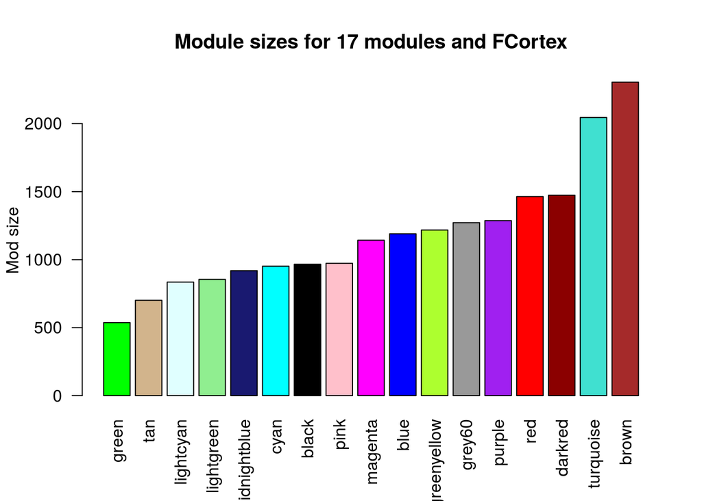

```r
# Display all modules in a specified tissue/network
CoExpNets::plotModSizes(tissue="FCortex",which.one="gtexv6")
```

```r
# Display network structure
Net_tissue <- "FCortex"
Database <- "gtexv6"
Eigengenes <- getNetworkEigengenes(which.one = Database, tissue = Net_tissue)
cat(Net_tissue, "network was obtained from", nrow(Eigengenes),
    "samples and has", ncol(Eigengenes), "modules\n")
```

```
## FCortex network was obtained from 108 samples and has 17 modules
```

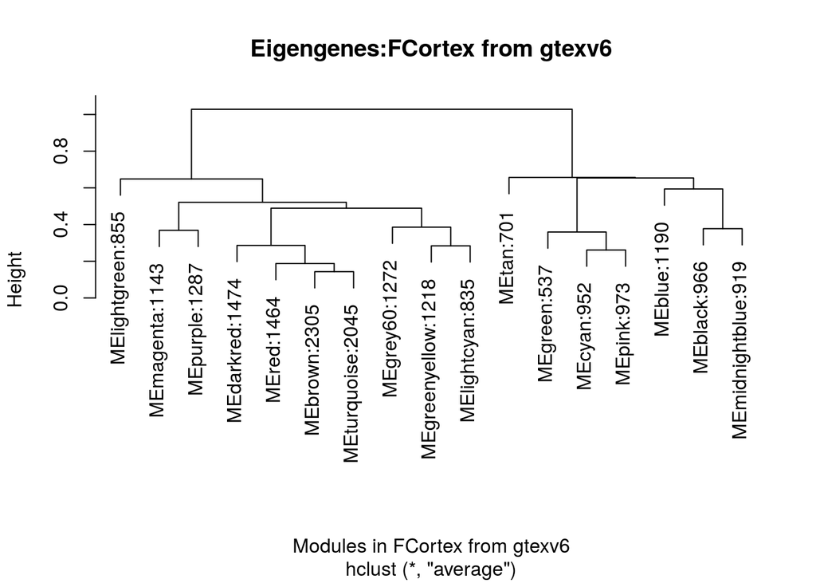

```r
plotEGClustering(which.one = Database, tissue = Net_tissue)
```

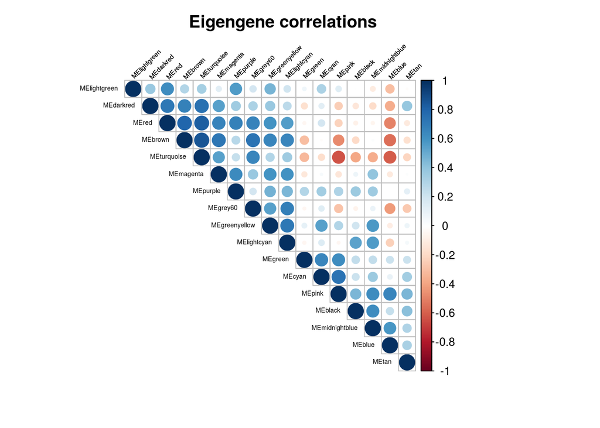

```r
# Display correlations between modules
corrplot(cor(Eigengenes), tl.srt = 45,
         tl.col = "black",
         type = "upper",
         tl.cex = 0.45,
         order = "hclust",
         title = paste0("Eigengene correlations"),
         mar = c(3, 2, 2.5, 4))
```

## 2.2. Gene set enrichment analysis

### NSL genes

First, the **NSL genes** were searched in the coexpression network.

```r
# Search genes of interest in specified tissue/network, including previously investigated KANSL1 ens.correction
NSL_report_gt <- reportOnGenes(tissue = "FCortex", genes = NSL_genes, which.one = "gtexv6", ens.correction = c("ENSG00000257382", "ENSG00000120071"))
# Select report
NSL_rep_gt <- NSL_report_gt$report
```

```r
# Convert report into dataframe
NSL_rep_gt_length <- nrow(NSL_rep_gt)
NSL_rep_gt <- data.frame(matrix(unlist(NSL_rep_gt), nrow = NSL_rep_gt_length, byrow = FALSE), stringsAsFactors=FALSE)
names(NSL_rep_gt)[1] <- "Gene"
names(NSL_rep_gt)[2] <- "ENSG"
names(NSL_rep_gt)[3] <- "MM"
names(NSL_rep_gt)[4] <- "Module"
names(NSL_rep_gt)[5] <- "Size"
names(NSL_rep_gt)[6] <- "GO_report"
names(NSL_rep_gt)[7] <- "PD_genes"
names(NSL_rep_gt)[8] <- "Preservation"
names(NSL_rep_gt)[9] <- "Cell_type"
names(NSL_rep_gt)[10] <- "Fisher"
# Order by p value
NSL_rep_gt <- NSL_rep_gt[order(NSL_rep_gt$Fisher), ]
# FDR correct p values
NSL_rep_gt$Fisher <- as.numeric(NSL_rep_gt$Fisher)
NSL_rep_gt$FDR <- p.adjust(NSL_rep_gt$Fisher, method="fdr")
```

The number of NSL genes is **9** and the number of genes in the search output was **9**, suggesting there were **0** genes missing from the search.

```r
# Print report without GO term and PD genes columns
NSL_rep_gt[c(-6, -7, -8)]
```

|  | Gene | ENSG | MM | Module | Size | Cell_type | Fisher | FDR |
| --- | --- | --- | --- | --- | --- | --- | --- | --- |
| 1 | HCFC1 | ENSG00000172534 | 0.7745 | red | 1464 | void | 0.002605 | 0.00586125 |
| 2 | KANSL1 | ENSG00000120071 | 0.8117 | red | 1464 | void | 0.002605 | 0.00586125 |
| 3 | OGT | ENSG00000147162 | 0.7796 | red | 1464 | void | 0.002605 | 0.00586125 |
| 4 | WDR5 | ENSG00000196363 | 0.9035 | red | 1464 | void | 0.002605 | 0.00586125 |
| 7 | KAT8 | ENSG00000103510 | 0.719 | darkred | 1474 | Neuron_Dopaminergic-External (p-value 3.228e-05). | 0.136800 | 0.20520000 |
| 8 | MCRS1 | ENSG00000187778 | 0.8494 | darkred | 1474 | Neuron_Dopaminergic-External (p-value 3.228e-05). | 0.136800 | 0.20520000 |
| 6 | KANSL3 | ENSG00000114982 | 0.8213 | magenta | 1143 | void | 0.409100 | 0.44420000 |
| 5 | KANSL2 | ENSG00000139620 | 0.7789 | greenyellow | 1218 | Neuron module in Cortex (p-value 1.736e-05). Neuron, pyramidal in network from Sugino/Winden (p-value 3.967e-05). | 0.429700 | 0.44420000 |
| 9 | PHF20 | ENSG00000025293 | 0.8647 | grey60 | 1272 | void | 0.444200 | 0.44420000 |

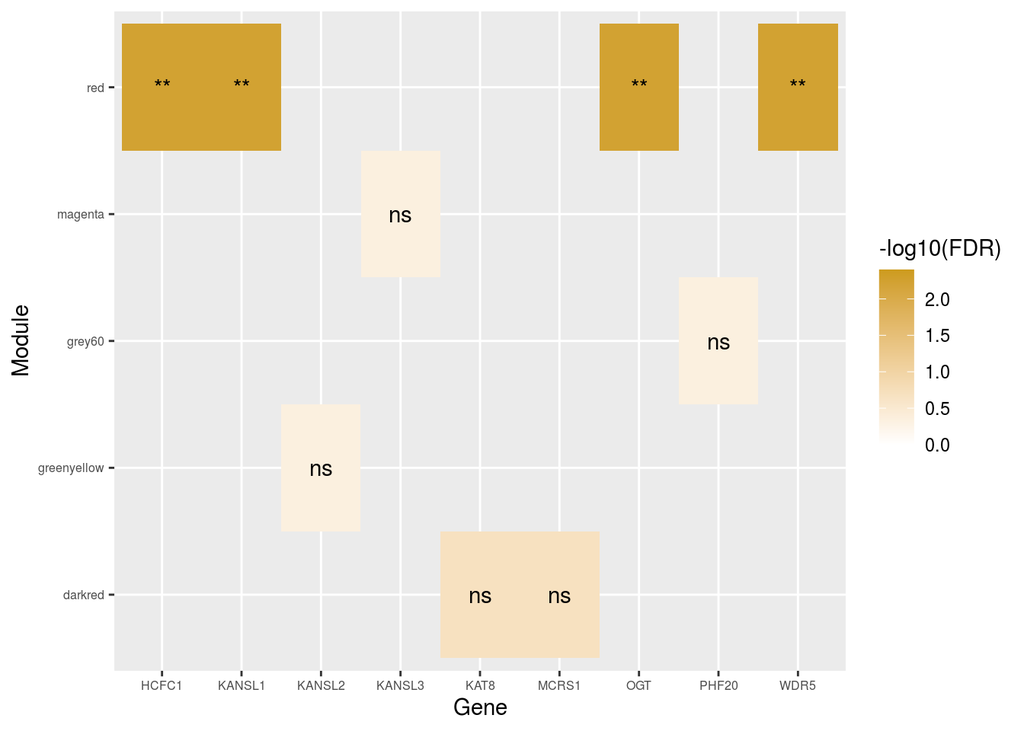

```r
# Store NSL enriched modules
NSL_gt_modules <- unique(NSL_rep_gt$Module)
# Select columns needed for figure
NSL_fig_gt <- data.frame(NSL_rep_gt$Module, NSL_rep_gt$Gene, NSL_rep_gt$FDR)
names(NSL_fig_gt)[names(NSL_fig_gt)=="NSL_rep_gt.FDR"] <- "FDR"
names(NSL_fig_gt)[names(NSL_fig_gt)=="NSL_rep_gt.Module"] <- "Module"
names(NSL_fig_gt)[names(NSL_fig_gt)=="NSL_rep_gt.Gene"] <- "Gene"
# Prep for figure
NSL_fig_gt$FDR <- as.numeric(NSL_fig_gt$FDR)
NSL_fig_gt$Module <- as.character(NSL_fig_gt$Module)
NSL_fig_gt <- dplyr::arrange(NSL_fig_gt, Module)
NSL_fig_gt$`-log10(FDR)` <- -log10(NSL_fig_gt$FDR)
# Produce plot
source(file.path(here::here("scripts", "CoExp_functions.R")))
ggplot(NSL_fig_gt, aes(Gene, Module)) +
  geom_tile(aes(fill = `-log10(FDR)`)) +
  geom_text(aes(label = signif.num(FDR))) +
  scale_fill_gradient(low = "white", high = "goldenrod3", limits = c(0,2.4)) +
  labs(y = "Module") +
  theme(axis.text = element_text(size = 6))
```

The NSL genes appeared in modules **red, darkred, magenta, greenyellow, grey60** in this GCN but were only significantly enriched in the **red** module. The eigengenes plot shows modules **darkred** and **red** to be relatively close together, as well as modules **greenyellow** and **grey60**, suggesting the genes within these pairs of modules may have some level of coexpression.

### PD mendelian genes

Then the PD mendelian list was searched and the results filtered for the NSL enriched modules.

```r
# Search genes of interest in specified tissue/network
PD_mendelian_report_gt <- reportOnGenes(tissue = "FCortex", genes = PD_mendelian_genes, which.one = "gtexv6")
# Select report
PD_mendelian_rep_gt <- PD_mendelian_report_gt$report
# Count number of genes in output
PD_mendelian_rep_gt_length <- nrow(PD_mendelian_rep_gt)
```

The number of PD mendelian genes is **43** and the number of genes in the search output was **39**, suggesting there were **4** genes missing from the search which needed to be identified.

```r
# Show missing genes
dplyr::setdiff(PD_mendelian_genes, PD_mendelian_rep_gt$gene)
```

```
## [1] "GBA"    "MAPT"   "PRKN"   "SLC6A3"
```

```r
# Check if any synonyms of the genes are present in networks
check_synonyms("FCortex", "gtexv6", PD_mendelian_genes, PD_mendelian_rep_gt$gene)
```

| hgnc_symbol | external_synonym | ensembl_gene_id |
| --- | --- | --- |
| PRKN | PARK2 | ENSG00000185345 |

**1** gene appeared in the network under an alias name, so this was replaced in the search list.

```r
# Replace this in the list of genes
PD_mendelian_gt_genes <- as.character(PD_mendelian_genes)
PD_mendelian_gt_genes[PD_mendelian_gt_genes=="PRKN"] <- "PARK2"
```

```r
# If genes still missing, check if ENSGs appear in source files
check_source_files("FCortex", "gtexv6", PD_mendelian_gt_genes, PD_mendelian_rep_gt$gene, file.path(here::here("data", "CoExp_source", "FCortex.resids.rds")))
```

| hgnc_symbol | ensembl_gene_id |
| --- | --- |
| GBA | ENSG00000177628 |
| MAPT | ENSG00000186868 |

**2 more** of the missing genes appeared in the network under these ENSGs, so an `ens.correction` was needed.

```r
# Return ENSGs that are in the networks
fromGeneName2Ensembl("GBA")
```

```
## [1] "ENSG00000262446"
```

```r
fromGeneName2Ensembl("MAPT")
```

```
## [1] "ENSG00000257437"
```

The remaining gene did not appear in the source files under any ENSG from ensembl, thus it was assumed this gene **does not appear in this dataset**. The search can was then repeated with the most complete gene list possible.

```r
# Again search genes of interest in specified tissue/network
PD_mendelian_report2_gt <- reportOnGenes(tissue = "FCortex", genes = PD_mendelian_gt_genes, which.one = "gtexv6", ens.correction = c("ENSG00000262446", "ENSG00000177628", "ENSG00000257437", "ENSG00000186868"))
# Select report
PD_mendelian_rep2_gt <- PD_mendelian_report2_gt$report
# Count number of genes in output
PD_mendelian_rep2_gt_length <- nrow(PD_mendelian_rep2_gt)
```

The number of genes in the final search output was **42**, showing there was **1** fewer gene than the original input list.

```r
# Convert report into dataframe
PD_mendelian_rep2_gt <- data.frame(matrix(unlist(PD_mendelian_rep2_gt), nrow = PD_mendelian_rep2_gt_length, byrow = FALSE), stringsAsFactors=FALSE)
names(PD_mendelian_rep2_gt)[1] <- "Gene"
names(PD_mendelian_rep2_gt)[2] <- "ENSG"
names(PD_mendelian_rep2_gt)[3] <- "MM"
names(PD_mendelian_rep2_gt)[4] <- "Module"
names(PD_mendelian_rep2_gt)[5] <- "Size"
names(PD_mendelian_rep2_gt)[6] <- "GO_report"
names(PD_mendelian_rep2_gt)[7] <- "PD_genes"
names(PD_mendelian_rep2_gt)[8] <- "Preservation"
names(PD_mendelian_rep2_gt)[9] <- "Cell_type"
names(PD_mendelian_rep2_gt)[10] <- "Fisher"
# Order by p value
PD_mendelian_rep2_gt <- PD_mendelian_rep2_gt[order(PD_mendelian_rep2_gt$Fisher), ]
```

```r
# Filter for NSL gene enriched modules
PD_mendelian_NSL_mod_gt <- PD_mendelian_rep2_gt %>%
  filter(Module %in% NSL_gt_modules)
# Print report without GO term and PD genes columns
PD_mendelian_NSL_mod_gt[, c(-6, -7, -8)]
```

| Gene | ENSG | MM | Module | Size | Cell_type | Fisher |
| --- | --- | --- | --- | --- | --- | --- |
| ATN1 | ENSG00000111676 | 0.5878 | red | 1464 | void | 0.3651 |
| ATXN2 | ENSG00000204842 | 0.8241 | red | 1464 | void | 0.3651 |
| PLA2G6 | ENSG00000184381 | 0.6555 | red | 1464 | void | 0.3651 |
| TH | ENSG00000180176 | 0.3817 | red | 1464 | void | 0.3651 |
| PARK7 | ENSG00000116288 | 0.8222 | darkred | 1474 | Neuron_Dopaminergic-External (p-value 3.228e-05). | 0.6025 |
| PINK1 | ENSG00000158828 | 0.6615 | darkred | 1474 | Neuron_Dopaminergic-External (p-value 3.228e-05). | 0.6025 |
| WDR45 | ENSG00000196998 | 0.7057 | darkred | 1474 | Neuron_Dopaminergic-External (p-value 3.228e-05). | 0.6025 |
| LYST | ENSG00000143669 | 0.8043 | greenyellow | 1218 | Neuron module in Cortex (p-value 1.736e-05). Neuron, pyramidal in network from Sugino/Winden (p-value 3.967e-05). | 0.7308 |
| SLC39A14 | ENSG00000104635 | 0.7396 | greenyellow | 1218 | Neuron module in Cortex (p-value 1.736e-05). Neuron, pyramidal in network from Sugino/Winden (p-value 3.967e-05). | 0.7308 |
| TBP | ENSG00000112592 | 0.7836 | magenta | 1143 | void | 0.9143 |

### PD sporadic genes

The PD sporadic list was also searched and the results filtered for the NSL enriched modules.

```r
# Search genes of interest in specified tissue/network
PD_GWAS_report_gt <- reportOnGenes(tissue = "FCortex", genes = PD_GWAS_genes, which.one = "gtexv6")
# Select report
PD_GWAS_rep_gt <- PD_GWAS_report_gt$report
# Count number of genes in output
PD_GWAS_rep_gt_length <- nrow(PD_GWAS_rep_gt)
```

The number of PD GWAS genes is **150** and the number of genes in the search output was **122**, suggesting there were **28** genes missing from the search which needed to be identified.

```r
# Show missing genes
dplyr::setdiff(PD_GWAS_genes, PD_GWAS_rep_gt$gene)
```

```
##  [1] "CCAR2"       "CSTA"        "DNAH17"      "GIN1"        "GPR65"
##  [6] "HIST1H4J"    "HLA-DQA1"    "HLA-DQA2"    "HLA-DQB1"    "HLA-DRA"
## [11] "HLA-DRB5"    "HLA-DRB6"    "KLHL7-DT"    "MAPT"        "MMRN1"
## [16] "NOD2"        "PPIP5K2"     "RAB29"       "RETREG3"     "SGF29"
## [21] "SLC4A1"      "TRIM10"      "TRIM31"      "TRIM40"      "VKORC1"
## [26] "WDR5B"       "ZNF668"      "ZSCAN16-AS1"
```

```r
# Check if any synonyms of the genes are present in networks
check_synonyms("FCortex", "gtexv6", PD_GWAS_genes, PD_GWAS_rep_gt$gene)
```

| hgnc_symbol | external_synonym | ensembl_gene_id |
| --- | --- | --- |
| CCAR2 | DBC1 | ENSG00000158941 |
| CCAR2 | KIAA1967 | ENSG00000158941 |
| KLHL7-DT | KLHL7-AS1 | ENSG00000230658 |
| RAB29 | RAB7L1 | ENSG00000117280 |
| RETREG3 | FAM134C | ENSG00000141699 |
| SGF29 | CCDC101 | ENSG00000176476 |

**5** genes appeared in the network under alias names, so these were replaced in the search list.

```r
# Replace this in the list of genes
PD_GWAS_gt_genes <- as.character(PD_GWAS_genes)
PD_GWAS_gt_genes[PD_GWAS_gt_genes=="CCAR2"] <- "KIAA1967"
PD_GWAS_gt_genes[PD_GWAS_gt_genes=="KLHL7-DT"] <- "KLHL7-AS1"
PD_GWAS_gt_genes[PD_GWAS_gt_genes=="RAB29"] <- "RAB7L1"
PD_GWAS_gt_genes[PD_GWAS_gt_genes=="RETREG3"] <- "FAM134C"
PD_GWAS_gt_genes[PD_GWAS_gt_genes=="SGF29"] <- "CCDC101"
```

```r
# If genes still missing, check if ENSGs appear in source files
check_source_files("FCortex", "gtexv6", PD_GWAS_gt_genes, PD_GWAS_rep_gt$gene, file.path(here::here("data", "CoExp_source", "FCortex.resids.rds")))
```

| hgnc_symbol | ensembl_gene_id |
| --- | --- |
| GIN1 | ENSG00000145723 |
| HLA-DQB1 | ENSG00000179344 |
| HLA-DRA | ENSG00000204287 |
| MAPT | ENSG00000186868 |
| PPIP5K2 | ENSG00000145725 |
| VKORC1 | ENSG00000167397 |
| ZNF668 | ENSG00000167394 |
| ZSCAN16-AS1 | ENSG00000269293 |

**8 more** of the missing genes appeared in the network under these ENSGs, so an `ens.correction` was needed.

```r
# Return ENSGs that are in the networks
fromGeneName2Ensembl("GIN1")
```

```
## [1] "ENSG00000263031"
```

```r
fromGeneName2Ensembl("HLA-DQB1")
```

```
## [1] "ENSG00000233209"
```

```r
fromGeneName2Ensembl("HLA-DRA")
```

```
## [1] "ENSG00000228987"
```

```r
fromGeneName2Ensembl("MAPT")
```

```
## [1] "ENSG00000257437"
```

```r
fromGeneName2Ensembl("PPIP5K2")
```

```
## [1] "ENSG00000262234"
```

```r
fromGeneName2Ensembl("VKORC1")
```

```
## [1] "ENSG00000255439"
```

```r
fromGeneName2Ensembl("ZNF668")
```

```
## [1] "ENSG00000232748"
```

```r
fromGeneName2Ensembl("ZSCAN16-AS1")
```

```
## [1] "ZSCAN16-AS1"
```

```r
# Return gene name that is attached to the correct ENSG of this gene
fromEnsembl2GeneName("ENSG00000269293")
```

```
## [1] "RP1-265C24.9"
```

```r
# Replace this in the search list
PD_GWAS_gt_genes[PD_GWAS_gt_genes=="ZSCAN16-AS1"] <- "RP1-265C24.9"
```

One of the above genes, *ZSCAN16-AS1*, could not be identified through the method of searching `fromGeneName2Ensembl`, but the ENSG was found instead using `fromEnsembl2GeneName` to be assigned to the gene name *RP1-265C24.9*, so this was replaced in the input list. The remaining genes did not appear in the source files under any ENSG from ensembl, thus it was assumed these genes **do not appear in this dataset**. A quick check on [GTEx](https://gtexportal.org/home/) itself for these genes displayed very low levels in the frontal cortex. The search was then repeated with the most complete gene list possible.

```r
# Again search genes of interest in specified tissue/network
PD_GWAS_report2_gt <- reportOnGenes(tissue = "FCortex", genes = PD_GWAS_gt_genes, which.one = "gtexv6", ens.correction = c("ENSG00000263031", "ENSG00000145723", "ENSG00000233209", "ENSG00000179344", "ENSG00000228987", "ENSG00000204287", "ENSG00000257437", "ENSG00000186868", "ENSG00000262234", "ENSG00000145725",  "ENSG00000255439", "ENSG00000167397", "ENSG00000232748", "ENSG00000167394"))
# Select report
PD_GWAS_rep2_gt <- PD_GWAS_report2_gt$report
# Count number of genes in output
PD_GWAS_rep2_gt_length <- nrow(PD_GWAS_rep2_gt)
```

The number of genes in the final search output was **135**, showing there were **15** fewer genes than the original input list.

```r
# Convert report into dataframe
PD_GWAS_rep2_gt <- data.frame(matrix(unlist(PD_GWAS_rep2_gt), nrow = PD_GWAS_rep2_gt_length, byrow = FALSE), stringsAsFactors=FALSE)
names(PD_GWAS_rep2_gt)[1] <- "Gene"
names(PD_GWAS_rep2_gt)[2] <- "ENSG"
names(PD_GWAS_rep2_gt)[3] <- "MM"
names(PD_GWAS_rep2_gt)[4] <- "Module"
names(PD_GWAS_rep2_gt)[5] <- "Size"
names(PD_GWAS_rep2_gt)[6] <- "GO_report"
names(PD_GWAS_rep2_gt)[7] <- "PD_genes"
names(PD_GWAS_rep2_gt)[8] <- "Preservation"
names(PD_GWAS_rep2_gt)[9] <- "Cell_type"
names(PD_GWAS_rep2_gt)[10] <- "Fisher"
# Order by p value
PD_GWAS_rep2_gt <- PD_GWAS_rep2_gt[order(PD_GWAS_rep2_gt$Fisher), ]
```

```r
# Filter for NSL modules
PD_GWAS_NSL_mod_gt <- PD_GWAS_rep2_gt %>%
  filter(Module %in% NSL_gt_modules)
# Print report without GO term and PD genes column
PD_GWAS_NSL_mod_gt[, c(-6, -7, -8)]
```

| Gene | ENSG | MM | Module | Size | Cell_type | Fisher |
| --- | --- | --- | --- | --- | --- | --- |
| BIN3 | ENSG00000147439 | 0.7796 | red | 1464 | void | 0.004146 |
| KIAA1967 | ENSG00000158941 | 0.907 | red | 1464 | void | 0.004146 |
| CTSB | ENSG00000164733 | 0.758 | red | 1464 | void | 0.004146 |
| DGKQ | ENSG00000145214 | 0.8707 | red | 1464 | void | 0.004146 |
| DLST | ENSG00000119689 | 0.7036 | red | 1464 | void | 0.004146 |
| GAK | ENSG00000178950 | 0.87 | red | 1464 | void | 0.004146 |
| GBAP1 | ENSG00000160766 | 0.7907 | red | 1464 | void | 0.004146 |
| HSD17B1 | ENSG00000108786 | 0.6629 | red | 1464 | void | 0.004146 |
| IGSF9B | ENSG00000080854 | 0.5689 | red | 1464 | void | 0.004146 |
| IP6K2 | ENSG00000068745 | 0.7882 | red | 1464 | void | 0.004146 |

[output cut: 32 more lines]

### Gene ontology terms

To examine the functional characteristics of these modules, the GO term enrichments annotated to these modules were extracted and simplified according to parent terms.

```r
# Obtain gprofiler2 annotations from the CoExpGTEx frontal cortex source files
e = read.csv(file.path(here::here("data", "CoExp_source", "netFCortex.9.it.50.rds_gprof.csv")),
             stringsAsFactors = FALSE)
# Extract all GO term enrichments from source file for modules of interest
NSL_GO = e[e$query.number %in% NSL_gt_modules & e$domain %in% c("BP", "CC", "MF"),]
NSL_GO_2 <- dplyr::select(NSL_GO, query.number, term.id, term.name, domain, p.value)
# Rename columns
names(NSL_GO_2)[names(NSL_GO_2)=="query.number"] <- "gene_list"
names(NSL_GO_2)[names(NSL_GO_2)=="term.id"] <- "go_id"
names(NSL_GO_2)[names(NSL_GO_2)=="domain"] <- "go_type"
names(NSL_GO_2)[names(NSL_GO_2)=="term.name"] <- "go_term"
# FDR correct p values
NSL_GO_2$p.value <- as.numeric(NSL_GO_2$p.value)
NSL_GO_2$FDR <- p.adjust(NSL_GO_2$p.value, method="fdr")
```

```r
# GO reduce all terms to parent terms
NSL_GO_red <- go_reduce(pathway_df = NSL_GO_2, threshold = 0.7, scores = NULL)
```

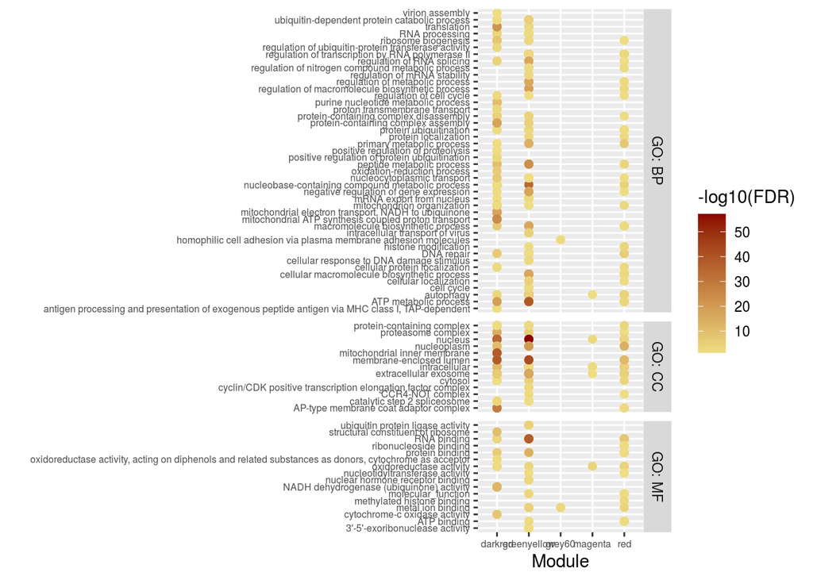

```r
# Format
NSL_GO_red$go_type[NSL_GO_red$go_type=="BP"] <- "GO: BP"
NSL_GO_red$go_type[NSL_GO_red$go_type=="MF"] <- "GO: MF"
NSL_GO_red$go_type[NSL_GO_red$go_type=="CC"] <- "GO: CC"
NSL_GO_red <- NSL_GO_red %>%
  tidyr::drop_na(parent_term)
# Plot
ggplot2::ggplot(NSL_GO_red, aes(x = gene_list, y = parent_term)) +
  geom_point(size = 2, aes(colour = -log10(`FDR`))) +
  scale_color_continuous(low = "lightgoldenrod", high = "red4") +
  facet_grid(go_type ~., scales = "free", space = "free") +
  labs(x = "Module", y = "") +
  theme(axis.text = element_text(size = 6))
```

## 2.2. Summary

The **frequency** of **genes** within each gene **list** apppearing in each of the **5 NSL enriched modules** was calculated.

```r
# Collate module results into one table
gt1 <- PD_mendelian_NSL_mod_gt['Module']
gt1['Gene_list'] <- "PD_mendelian"
gt2 <- PD_GWAS_NSL_mod_gt['Module']
gt2['Gene_list'] <- "PD_GWAS"
gt_mods_list <- do.call(rbind, list(gt1, gt2))
# Display as frequency of each module within each list
gt_mod_freq <- with(gt_mods_list, table(Module, Gene_list))
gt_mod_freq <- as.data.frame.matrix(gt_mod_freq)
```

```r
knitr::kable(gt_mod_freq[c(5,1,4,2,3),])
```

|  | PD_GWAS | PD_mendelian |
| --- | --- | --- |
| red | 19 | 4 |
| darkred | 9 | 3 |
| magenta | 5 | 1 |
| greenyellow | 3 | 2 |
| grey60 | 6 | 0 |

The **significance** of the **enrichments** of each **gene list** within each of the **5 NSL enriched modules** was also calculated. P-values were **FDR-corrected** before summarising.

```r
# FDR correct p values
PD_mendelian_rep2_gt$FDR <- p.adjust(PD_mendelian_rep2_gt$Fisher, method = "fdr")
PD_GWAS_rep2_gt$FDR <- p.adjust(PD_GWAS_rep2_gt$Fisher, method = "fdr")
```

```r
# Collate module results into one table
gts1 <- data.frame(PD_mendelian_rep2_gt$Module, PD_mendelian_rep2_gt$FDR)
names(gts1)[names(gts1)=="PD_mendelian_rep2_gt.FDR"] <- "FDR"
names(gts1)[names(gts1)=="PD_mendelian_rep2_gt.Module"] <- "Module"
gts1$Gene_list <- "PD_mendelian"
gts2 <- data.frame(PD_GWAS_rep2_gt$Module, PD_GWAS_rep2_gt$FDR)
names(gts2)[names(gts2)=="PD_GWAS_rep2_gt.FDR"] <- "FDR"
names(gts2)[names(gts2)=="PD_GWAS_rep2_gt.Module"] <- "Module"
gts2$Gene_list <- "PD_GWAS"
gt_pvals_list <- dplyr::bind_rows(gts1, gts2)
# Display as true/false table
gt_TF <- gt_pvals_list %>%
  dplyr::distinct() %>%
  tidyr::spread(Gene_list, FDR)
gt_TF <- dplyr::filter(gt_TF, Module %in% NSL_gt_modules)
gt_TF <- tibble::column_to_rownames(gt_TF, var = "Module")
```

```r
knitr::kable(gt_TF[c(5,1,4,2,3),])
```

|  | PD_GWAS | PD_mendelian |
| --- | --- | --- |
| red | 0.0294584 | 0.5111400 |
| darkred | 0.8170991 | 0.7668182 |
| magenta | 0.9431929 | 0.9228000 |
| greenyellow | 0.9975000 | 0.8769600 |
| grey60 | 0.9431929 | NA |

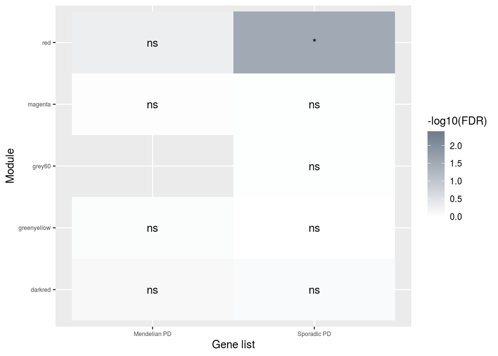

```r
# Filter out modules without NSL genes
melt_summ <- gt_pvals_list %>%
  dplyr::filter(Module %in% NSL_gt_modules) %>%
  dplyr::distinct()
# Prep for figure
melt_summ$Gene_list[melt_summ$Gene_list=="PD_mendelian"] <- "Mendelian PD"
melt_summ$Gene_list[melt_summ$Gene_list=="PD_GWAS"] <- "Sporadic PD"
melt_summ$FDR <- as.numeric(melt_summ$FDR)
melt_summ$Module <- as.character(melt_summ$Module)
melt_summ$Gene_list <- as.character(melt_summ$Gene_list)
melt_summ <- dplyr::arrange(melt_summ, Module)
melt_summ$`-log10(FDR)` <- -log10(melt_summ$FDR)
# Plot
ggplot(melt_summ, aes(Gene_list, Module)) +
  geom_tile(aes(fill = `-log10(FDR)`)) +
  geom_text(aes(label = signif.num(FDR))) +
  scale_fill_gradient(low = "white", high = "lightsteelblue4", limits = c(0, 2.4)) +
  labs(y = "Module", x = "Gene list") +
  theme(axis.text = element_text(size = 6))
```